# DATA 624 Homework 3

```r
bricks <- aus_production %>%
  filter(!is.na(Bricks))

bricks_fit <- bricks %>%
  model(SNAIVE(Bricks ~ lag("year"))) %>%
  forecast(h=4)
```

Below we can observe that the seasonal naive model captures the high seasonality of our data as it attempts to predict the future brick production.

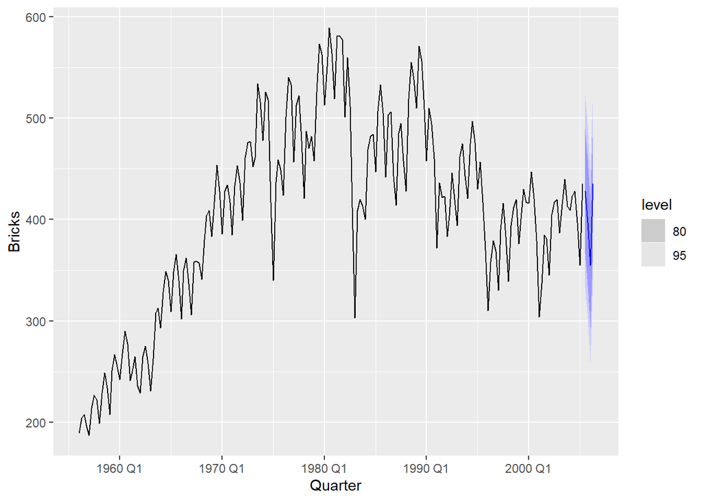

```r
bricks_fit %>% autoplot(bricks)
```

-NSW Lambs (`aus_livestock`)

In the data below, we may see that there are periods of trends that go up or down and unpredictable changes in direction. I believe we could use the naive method for these data as I believe it’s following a random walk.

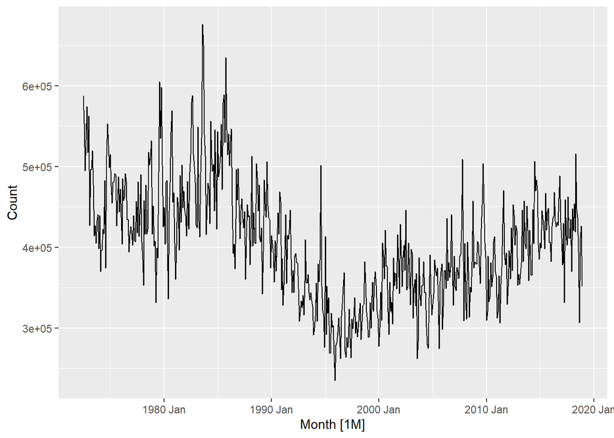

```r
aus_livestock %>%
  filter(State=="New South Wales" & Animal=="Lambs") %>%
  autoplot(Count)
```

```r
lambs <- aus_livestock %>%
  filter(State=="New South Wales" & Animal=="Lambs")

lambs_fit <- lambs %>%
  model(NAIVE(Count)) %>%
  forecast(h=12)
```

The naive model seems to be the most appropriate as we’re not sure exactly where the data may go and this method takes the value of the last observation for the forecast.

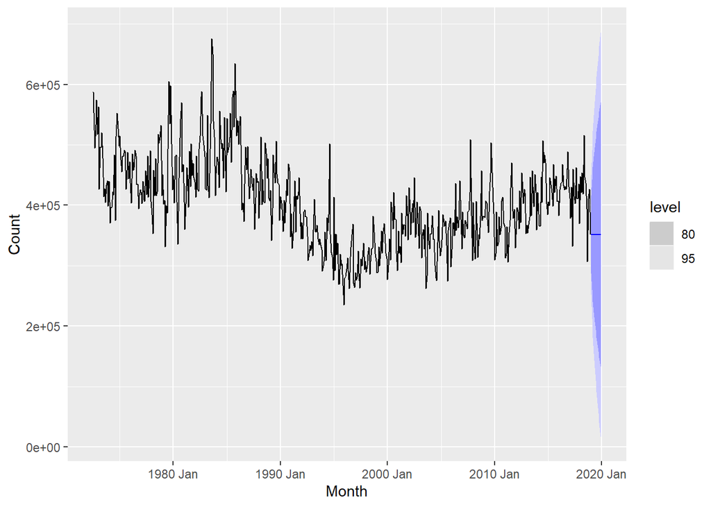

```r
lambs_fit %>% autoplot(lambs)
```

-Household wealth (`hh_budget`).